# Photo Analytics

```r
library(ggplot2)
library(dplyr)
library(tidyr)
library(reshape2)
library(RColorBrewer)
library(knitr)
library(kableExtra)
```

This script is a simple tool to clean a bunch of exif data that I dumped into a csv using exiftool and plotted to check a few things about the photos I took when I was on a trip around Europe last year.

### Why am I doing this?

I only had one lens on me at the time, and I often found myself in camera shops because I felt my lens was limiting the kind of photos I could take. So I figured I might look at the exif data from the photos I took and see whether I was bumping up against constraints imposed by the kit zoom lens I was using. So the question I’m trying to answer is:

> Is my lens holding me back? If so, what kind of lens should I buy to get rid of that barrier?

The key features in a lens are the focal length for a prime lens, or focal length range for a zoom, and the maximum size of the aperture (the opening that lets in the light), so I’ll focus on those.

### Get Data

The first thing to do is to run the system command that gets the exif data. This is a pretty lazy way of getting the data out of exiftool to be honest. The tool has lots and lots of [options for getting specific data out](https://www.sno.phy.queensu.ca/~phil/exiftool/exiftool_pod.html#READING-EXAMPLES) which can give you the exact data you’re after. My main reason for doing it this way was that I just wanted to get the data into r with the least amount of hassle. I would genuinely like to know if it’s possible to bring it straight into R rather than having the intermediate csv though.

```r
system2(command = 'exiftool',
        args = c('-csv', '-r',
                 '-DateTimeOriginal', '-Model',
                 '-MaxApertureValue', '-Aperture', '-FocalLength',
                 paste0('"/Volumes/SO SPACE!/Photos/17-05"*')),
        stdout = './inputs/my_photos.csv')
exif_raw <- read.csv('./inputs/my_photos.csv', stringsAsFactors = F)
```

### Clean

To begin with I’ll remove any image entries that don’t have a complete set of the data I’m looking at. But for peace of mind we’ll take a look at what was removed.

```r
kable(exif_raw[!complete.cases(exif_raw),]) %>%
  kable_styling(bootstrap_options = c("bordered") , full_width = F)
```

|  | SourceFile | DateTimeOriginal | Model | MaxApertureValue | Aperture | FocalLength |
| --- | --- | --- | --- | --- | --- | --- |
| 1466 | /Volumes/SO SPACE!/Photos/17-05-21 Vienna/MAH05953.MP4 |  |  | NA | NA |  |

It looks like we picked up a movie file (.mp4) in the initial batch of data, and I’m not particularly interested in that so I’m happy to let this one go.

### Explore

Seasoned photographers will recognise here that there’s an inherent tension between aperture and focal length. I’ll spare you the physics and give you a chart instead:

```r
fl_aperture <- exif_clean %>%
melt(id.vars = c("FocalLength", "Model"),
     measure.vars = c("MaxApertureValue", "Aperture"),
     variable.name = "Data Source") %>%
mutate(`Data Source` = ifelse(`Data Source` == "Aperture", "Actual Photo", "Aperture Limit"),
       value = ifelse(Model == "ILCE-6000", value, value*2/1.53),
       FocalLength = ifelse(Model == "ILCE-6000", FocalLength, FocalLength*2/1.53),
       Model = ifelse(Model == "ILCE-6000", "A6000 (+Sony 16-50mm f3.5-5.6)", "Pen-F (+Olympus 17mm f1.8)"))
x_breaks <- seq(16, 50, by = 2)
scatter_plot <- fl_aperture %>%
  ggplot(aes(x = FocalLength, y = value, colour = Model, alpha = `Data Source`, fill = `Data Source`)) +
  geom_point(size = 3) +
  scale_x_continuous(breaks = x_breaks) +
  scale_alpha_manual(values = c(0.08,1)) +
  scale_fill_manual(values = c('black','grey')) +
  labs(x = "Focal Length (mm APS-C Equivalent)",
       y = "Aperture (smaller number is better in this context)") +
  coord_cartesian(xlim = c(16, 50), ylim = c(0, 30))
```

[figure not shown]

The darker dots that sit at the bottom of the chart mark the minimum f-stop (which corresponds to the largest aperture size) at a given focal length. There are a few things raised by this chart:

1. I got to try an Olympus Pen with a 17mm f1.8 prime lens on a tour I did in Frankfurt, and it demonstrates pretty clearly what a new piece of kit can do to expand your creative scope. [^1]
2. It stands to reason from this chart that some, or many, photos were taken at the aperture limit, but to see exactly how often I set the aperture at the limit we need another chart.

### Analyse

What I’d like to do is get an idea of how many photos were taken at any given combination of aperture and focal length:

```r
exif_fl_ap <- fl_aperture %>%
  filter(`Data Source` == "Actual Photo",
         Model == "A6000 (+Sony 16-50mm f3.5-5.6)") %>%
  mutate(FocalLength_bin = round(FocalLength),
         Aperture_bin = value) %>%
  dcast(FocalLength_bin~Aperture_bin, value.var = "value") %>%
  melt(id = c("FocalLength_bin"),
       variable.name = "Aperture_bin",
       value.name = "Count")

heatmap_fl_ap <- expand.grid(FocalLength = seq(min(exif_fl_ap$FocalLength_bin),
                                               max(exif_fl_ap$FocalLength_bin),
                                               1),
                             Aperture = unique(exif_fl_ap$Aperture_bin)) %>%
  left_join(exif_fl_ap, by = c("FocalLength" = "FocalLength_bin", "Aperture" = "Aperture_bin")) %>%
  mutate(Count = ifelse(is.na(Count), 0, Count))

heatmap_plot <- ggplot(heatmap_fl_ap, aes(x = FocalLength, y = Aperture)) +
  geom_raster(aes(fill = Count), interpolate = FALSE) +
  scale_x_continuous(breaks = x_breaks) +
  scale_fill_gradientn(colours = rev(brewer.pal(5, "RdYlBu"))) +
  theme(panel.background = element_blank())
```

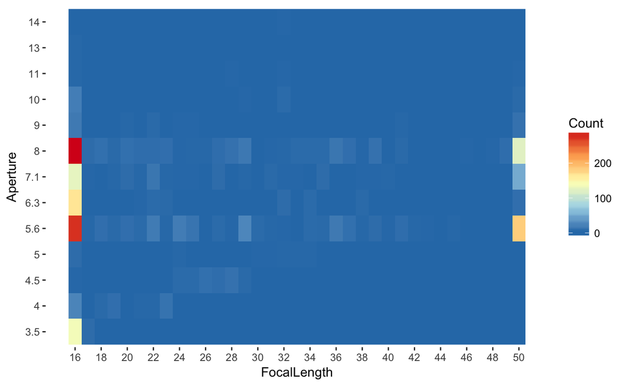

### Some final remarks

There’s a lot more to dig into here. For one, I deliberately keep my aperture in the 5.6 - 8 range because that’s where I get the best image quality, so seeing a large number of shots at 3.5 still raises my eyebrow slightly. Maybe I should get a wide angle lens with a large aperture? Sounds expensive …

On the data front though, there’s a lot more on offer in exiftool. I haven’t looked at how I could better use ISO or how my photography style has changed over time, but all of that is doable.

[^1]: I have corrected both the aperture and focal length calculations for the effect of sensor size to get an apples to apples comparison between the Sony and the Olympus. In this case the micro 4/3 numbers were multiplied by 2/1.53 to convert them to an APS-C equivalent number.